# Short reads evaluation with [FastQC](https://www.bioinformatics.babraham.ac.uk/projects/fastqc/)

# 1 Fastqc Evaluation

## 1.1 Evaluation of reads before trimming

- HTML report: 100M_emerald_6.5_Sample10_L1.R2.paired.trimmed.fq
- fastqc_data.txt: 100M_emerald_6.5_Sample10_L1.R2.paired.trimmed.fq
- summary.txt: 100M_emerald_6.5_Sample10_L1.R2.paired.trimmed.fq

## 1.2 Evaluation of reads after trimming

- HTML report: Trimmomatic on 100M_emerald_6.5_Sample10_L1.R2.paired.trimmed.fq (R2 paired)
- fastqc_data.txt: Trimmomatic on 100M_emerald_6.5_Sample10_L1.R2.paired.trimmed.fq (R2 paired)
- summary.txt: Trimmomatic on 100M_emerald_6.5_Sample10_L1.R2.paired.trimmed.fq (R2 paired)

# 2 Fastqc output visualization

## 2.1 Overview

| MODULE | 100M_emerald_6.5_Sample10_L1.R2.paired.trimmed.fq(before) | Trimmomatic on 100M_emerald_6.5_Sample10_L1.R2.paired.trimmed.fq (R2 paired)(after) |
| --- | --- | --- |
| Basic Statistics | PASS | PASS |
| Per base sequence quality | PASS | PASS |
| Per tile sequence quality | PASS | PASS |
| Per sequence quality scores | PASS | PASS |
| Per base sequence content | WARN (!) | WARN (!) |
| Per sequence GC content | PASS | PASS |
| Per base N content | PASS | PASS |
| Sequence Length Distribution | WARN (!) | WARN (!) |
| Sequence Duplication Levels | PASS | PASS |
| Overrepresented sequences | WARN (!) | WARN (!) |
| Adapter Content | PASS | PASS |
| Kmer Content | FAIL (X) | WARN (!) |

## 2.2 Visualization by data module

- Define a function to extract outputs for each module from fastqc output

### 2.2.1 Per base sequence quality

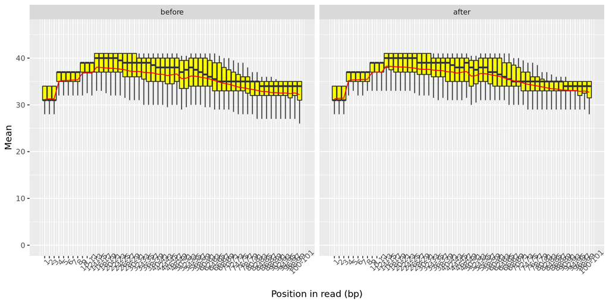

### 2.2.2 Per tile sequence quality

[interactive chart not shown]

### 2.2.3 Per sequence quality score

[interactive chart not shown]

### 2.2.4 Per base sequence content

[interactive chart not shown]

### 2.2.5 Per sequence GC content

[interactive chart not shown]

### 2.2.6 Per base N content

[interactive chart not shown]

### 2.2.7 Sequence Length Distribution

[interactive chart not shown]

### 2.2.8 Sequence Duplication Levels

[interactive chart not shown]

### 2.2.9 Adapter Content

[interactive chart not shown]

### 2.2.10 Kmer Content

#### 2.2.10.1 Before

| X.Sequence | Count | PValue | Obs.Exp.Max | Max.Obs.Exp.Position |
| --- | --- | --- | --- | --- |
| CGCACTA | 275 | 0.0000000 | 43.97288 | 7 |
| GTCGCAC | 65 | 0.0000039 | 41.34203 | 5 |
| ATAGGCT | 65 | 0.0000039 | 41.34203 | 8 |
| TCGCACT | 380 | 0.0000000 | 36.53693 | 6 |
| GCACTAC | 210 | 0.0000000 | 36.25631 | 8 |
| TATAGGC | 75 | 0.0000103 | 35.82976 | 7 |
| CGTCGCA | 65 | 0.0001873 | 34.45169 | 4 |
| TAGGCTG | 65 | 0.0001873 | 34.45169 | 9 |
| CCCCCGT | 80 | 0.0000159 | 33.65772 | 1 |
| GCACTAT | 135 | 0.0000000 | 33.17571 | 8 |
| GTCCCCA | 125 | 0.0000000 | 32.31141 | 1 |
| CGCACTG | 90 | 0.0000359 | 29.85814 | 7 |
| CGCGTAT | 60 | 0.0052601 | 29.85813 | 3 |
| ATACGAT | 75 | 0.0004336 | 29.85813 | 4 |
| CCCAGGT | 225 | 0.0000000 | 29.85813 | 2 |
| TGGTTAA | 185 | 0.0000000 | 29.33038 | 92-93 |
| CGATGAA | 385 | 0.0000000 | 28.99561 | 94-95 |
| GATGAAC | 330 | 0.0000000 | 28.75398 | 94-95 |
| GTCGCTA | 35 | 0.0066024 | 28.50600 | 74-75 |
| GCACTGC | 110 | 0.0000043 | 28.50095 | 8 |

#### 2.2.10.2 After

| X.Sequence | Count | PValue | Obs.Exp.Max | Max.Obs.Exp.Position |
| --- | --- | --- | --- | --- |
| CCCCCTA | 40 | 0.0009011 | 42.77796 | 2 |
| GGCCCGT | 50 | 0.0000527 | 42.73451 | 1 |
| CTTACGT | 40 | 0.0009056 | 42.73451 | 1 |
| GGTCCGT | 70 | 0.0000089 | 36.62958 | 1 |
| GGGCCCA | 50 | 0.0027106 | 34.18761 | 1 |
| CCCAGGT | 215 | 0.0000000 | 33.82444 | 2 |
| ACGCTCG | 90 | 0.0000000 | 33.79779 | 90-91 |
| CCCGTTG | 95 | 0.0000019 | 31.56553 | 3 |
| CAGTTAC | 55 | 0.0042001 | 31.26381 | 6 |
| CGGTTAG | 55 | 0.0000023 | 30.97269 | 60-61 |
| CGCTGTA | 85 | 0.0000000 | 30.60810 | 48-49 |
| GCCCGAA | 70 | 0.0003787 | 30.55569 | 2 |
| CCAGGGT | 100 | 0.0000030 | 29.91416 | 1 |
| TCTCACG | 120 | 0.0000000 | 29.31745 | 86-87 |
| TCGAGTA | 90 | 0.0000000 | 29.04224 | 94-95 |
| CGAGAAG | 240 | 0.0000000 | 29.04224 | 94-95 |
| AGCGGTC | 95 | 0.0000000 | 28.80116 | 66-67 |
| TAGGCGG | 120 | 0.0000004 | 28.72305 | 9 |
| ATCACGA | 105 | 0.0000041 | 28.67021 | 7 |
| CAGCGTT | 75 | 0.0005672 | 28.51864 | 2 |

# 4 References

- Bioinformatics, Babraham (2014). FastQC.
- Allaire, J and Cheng, Joe and Xie, Yihui and McPherson, Jonathan and Chang, Winston and Allen, Jeff and Wickham, Hadley and Atkins, Aron and Hyndman, Rob (2016). rmarkdown: Dynamic Documents for R, 2016. In R package version 0.9, 6.
- Xie, Yihui (2015). Dynamic Documents with R and knitr, CRC Press, Vol.29.
- Carson Sievert and Chris Parmer and Toby Hocking and Scott Chamberlain and Karthik Ram and Marianne Corvellec and Pedro Despouy (2017). plotly: Create Interactive Web Graphics via ‘plotly.js’. R package version 4.6.0. [Link]
- Wickham, H. (2016). ggplot2: elegant graphics for data analysis. Springer. Chicago